# Discrete Random Data

Monika Peteva Petkova

mpetevap@uni-sofia.bg, monikapetevapetkova@gmail.com

2021

In statistics there are $3$ types of random variables:

- **Discrete /Дискретни/**
- **Continuous /Непрекъснати/**
- **Mixtures /Смеси/**

In this course we are going to review only the first two.

Let’s first explain some terms that we will need to use.

- For discrete random variable:
  - **Probability mass function (PMF) /Ред на разпределение/** - is a function that gives the probability that a discrete random variable is exactly equal to some value.
    $$P_X(x_i) := P(X = x_i)$$
    Example
    $$P_X(x_i) = P(X = x_i) = \begin{cases} 0.2, & x_i = 1 \\ 0.5, & x_i = 3 \\ 0.3, & x_i = 7 \\ 0, & otherwise \end{cases}$$

[figure not shown]

[output not shown]

$$F_X(x) := P(X \leq x) = \sum_{i: x_i \leq x}P(X = x_i)$$

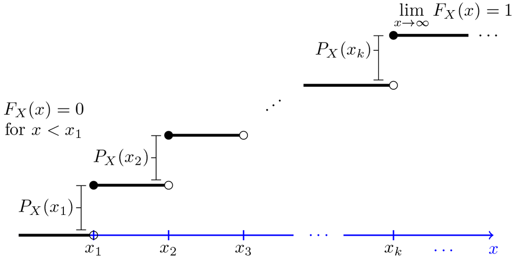

Example:

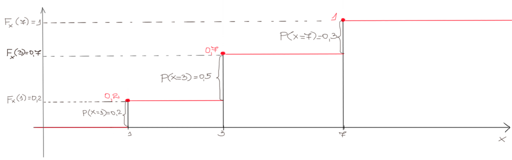

- For absolutely continuous random variable:
  - **Probability density function (PDF) /Плътност на разпределение/** - If the probability density function $f_X(x)$ exist, it is a non-negative function such that:
    $$F_X(x_0) = \int_{-\infty}^{x_0}f_X(x)dx$$
    and
    $$\int_{-\infty}^{\infty}f_X(x)dx = 1$$

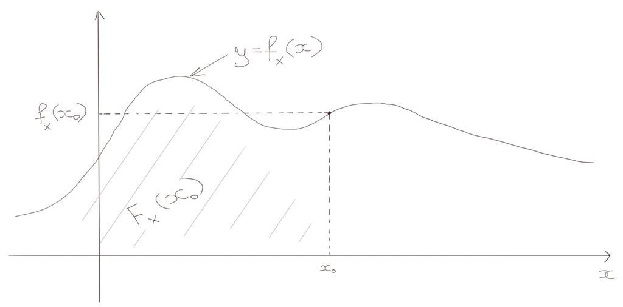

  - **Cumulative distribution function (CDF) /Кумулативна функция на разпределение/** - is the probability that a random variable $X$ will take a value less than or equal to $x$.
    $$F_X(x) := P(X \leq x)$$
- **Moments** - quantitative measures related to the shape of the function
  - **First moment /Expectation, Mean/**
    $$\mu = E[X] = \int_{-\infty}^{+\infty}{xdF_X(x)}$$
  - **Second central moment /Variance/**
    $$\sigma^2 = Var[X] = D[X] = E[(X - E[X])^2] =$$
    $$= E[X^2 - 2XE[X] + (E[X])^2] =$$
    $$= E[X^2] - 2E[X]E[X] + (E[X])^2 =$$
    $$= E[X^2] - (E[X])^2$$
  - **Third standardized moment /Skewness/**
    $$\operatorname{E}\left[\left(\frac{X - \mu}{\sigma}\right)^3 \right] = \frac{E(X - \mu)^3}{\sigma^3}$$

[figure not shown]

    We also say that the data on the first graphic is **left-skewed** and the data on the second graphic is **right-skewed**.

  - **Fourth standardized moment**
    $$\operatorname{E}\left[\left(\frac{X - \mu}{\sigma}\right)^4 \right] = \frac{E(X - \mu)^4}{\sigma^4}$$
    $$\text{Kurtosis} = \text{Fourth standardized moment} - 3$$

  They are also named: **Mesokurtic /Normal/**, **Leptokurtic**, **Platykurtic**

# Discrete Distriutions

## Discrete uniform distribution /Дискретно равномерно разпределение/

**Discrete uniform distribution** contains a known, finite number of outcomes equally likely to happen. In statistics we use the notation **DU** and **DUnif**.
$$X \in DU(a, b)$$
$$X \in DUnif(a, b)$$
Where $a$ is the min, $b$ is the max possible value and $n = b - a + 1$.

**Probability mass function (PMF)**
$$P_X(x_i) = P(X = x_i) = \begin{cases} \frac{1}{n}, & x_i = a, \: a+1, \: ..., \: b \\ 0, & otherwise \end{cases}$$

[figure not shown]

**Cumulative distribution function (CDF)**

[figure not shown]

**Mean**
$$\mu = E[X] = \int_{-\infty}^{+\infty}{xdF_X(x)} = \sum_{i = a}^{b}{iP(X = i)} =$$
$$= \sum_{i = a}^{b}{i\frac{1}{n}} = \frac{1}{n}\sum_{i = a}^{b}{i} = \frac{1}{n}(a + ... + b) =$$
$$= \frac{[(a-1)+1] + ... + [(a-1)+(b-(a-1))]}{n} =$$
$$= \frac{n(a-1)+\sum_{i=1}^{b-a+1}{i}}{n} = \frac{n(a-1)+\sum_{i=1}^{n}{i}}{n} =$$
$$= (a-1) + \frac{n(n+1)}{2n} = a-1 + \frac{b-a+2}{2} =$$
$$= \frac{a + b}{2}$$
**Variance**
$$\sigma^2 = \frac{(b - a + 1)^2 - 1}{12}$$

### Example 1

As a first example let’s consider rolling a regular dice. It will have discrete uniform distribution $DUnif(1, 6)$.

**Probability mass function (PMF)**

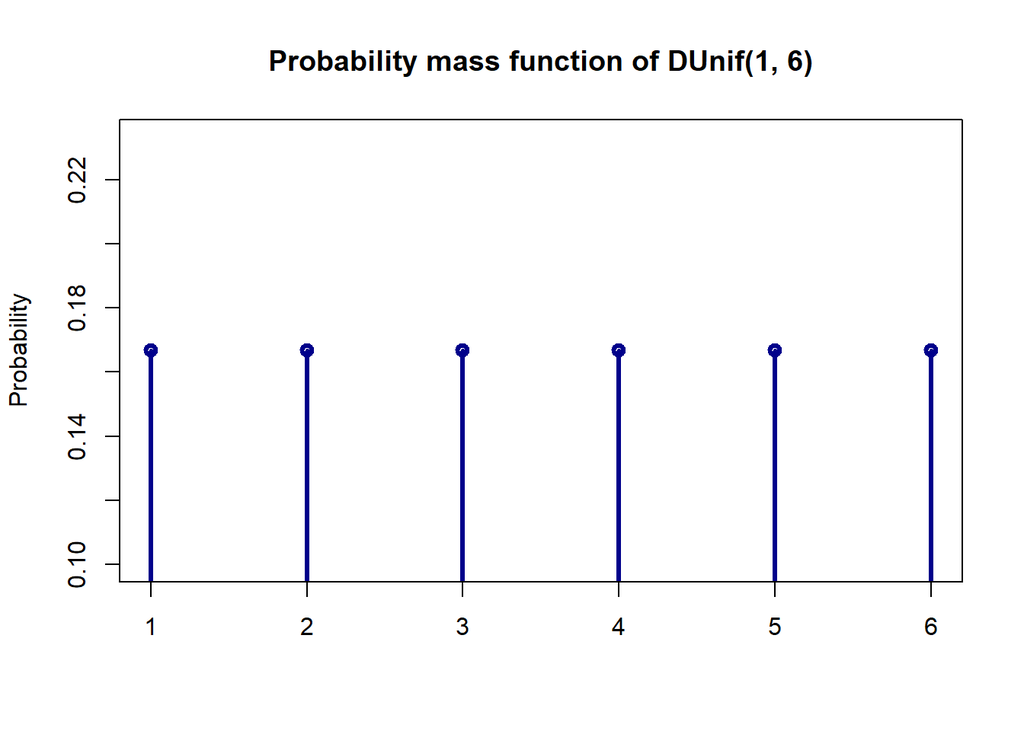

```r
> min <- 1; max <- 6
> n <- max - min + 1
> 1/n
[1] 0.1666667
> plot(min:max, rep(1/n, n),
+      main = "Probability mass function of DUnif(1, 6)",
+      xlab = "", ylab = "Probability",
+      type = "h", lwd = 3, col = "darkblue")
> points(min:max, rep(1/n, n),
+        type = "p", lwd = 3, col = "darkblue")
```

**Cumulative distribution function (CDF)**

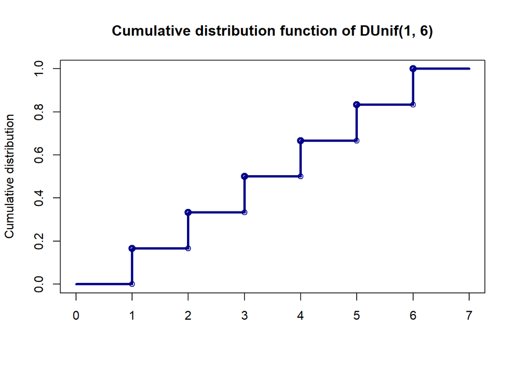

```r
> 1/n
[1] 0.1666667
> plot((min-1):(max+1), c(0, cumsum(rep(1/n, n)), 1),
+      main = "Cumulative distribution function of DUnif(1, 6)",
+      xlab = "", ylab = "Cumulative distribution",
+      type = "s", lwd = 3, col = "darkblue")
> points(min:max, cumsum(rep(1/n, n)),
+        type = "p", lwd = 3, col = "darkblue")
> points(min:max, c(0, cumsum(rep(1/n, n-1))),
+        type = "p", lwd = 1, col = "darkblue")
```

We can simulate an outcome from a dice rolling using the `sample` function.

```r
> sample(1:6, size = 1, replace = TRUE)
[1] 5
```

You can see that every time it generates a new number

```r
> sample(1:6, size = 1, replace = TRUE)
[1] 4
> sample(1:6, size = 1, replace = TRUE)
[1] 1
> sample(1:6, size = 1, replace = TRUE)
[1] 2
```

But if we want for example to save our work and to continue later on or to send it to a friend or you need someone to check it it is useful always to generate the same random numbers. You can do this using the `set.seed` function.

```r
> set.seed(10)
> sample(1:6, size = 1, replace = TRUE)
[1] 3
> set.seed(10)
> sample(1:6, size = 1, replace = TRUE)
[1] 3
> set.seed(10)
> sample(1:6, size = 1, replace = TRUE)
[1] 3
```

Let’s simulate 10 outcomes from rolling a regular dice.

```r
> sample(1:6, size = 10, replace = TRUE)
 [1] 1 2 4 6 3 2 2 2 5 6
```

### Example 2

Another example can be a regular coin toss. It will have discrete uniform distribution $DUnif(0, 1)$.

**Probability mass function (PMF)**

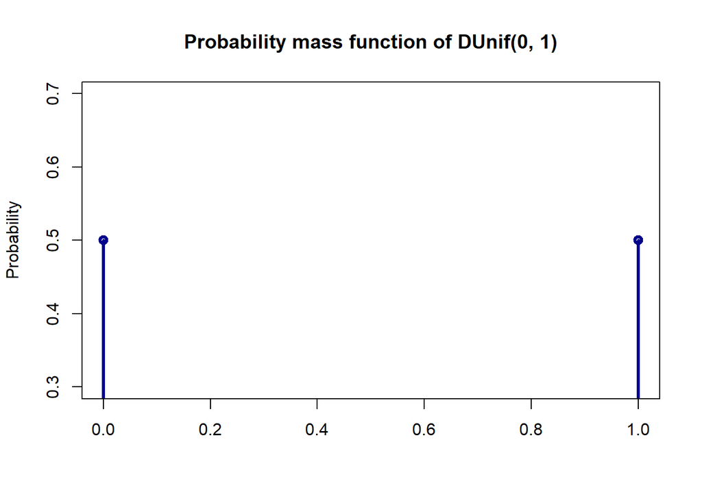

```r
> min <- 0; max <- 1
> n <- max - min + 1
> plot(min:max, rep(1/n, n),
+      main = "Probability mass function of DUnif(0, 1)",
+      xlab = "", ylab = "Probability",
+      type = "h", lwd = 3, col = "darkblue")
> points(min:max, rep(1/n, n),
+        type = "p", lwd = 3, col = "darkblue")
```

**Cumulative distribution function (CDF)**

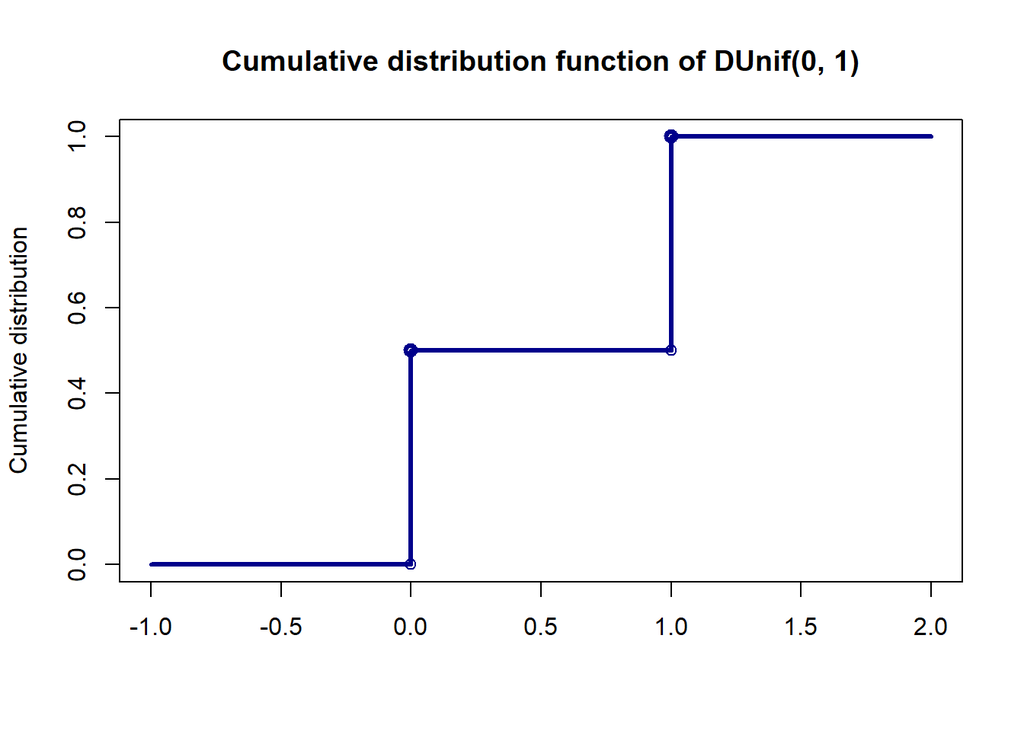

```r
> plot((min-1):(max+1), c(0, cumsum(rep(1/n, n)), 1),
+      main = "Cumulative distribution function of DUnif(0, 1)",
+      xlab = "", ylab = "Cumulative distribution",
+      type = "s", lwd = 3, col = "darkblue")
> points(min:max, cumsum(rep(1/n, n)),
+        type = "p", lwd = 3, col = "darkblue")
> points(min:max, c(0, cumsum(rep(1/n, n-1))),
+        type = "p", lwd = 1, col = "darkblue")
```

We can simulate 10 outcomes from tossing a symmetric coin.

```r
> sample(c("Head","Tail"), size = 10, replace = TRUE)
 [1] "Head" "Tail" "Head" "Head" "Tail" "Tail" "Head" "Head" "Head" "Head"
```

### Example 3

Another example can be the drawing of a number from 6 of 49 lottery numbers. If we have equal probability to draw each number we will have discrete uniform distribution $DUnif(1, 49)$.

**Probability mass function (PMF)**

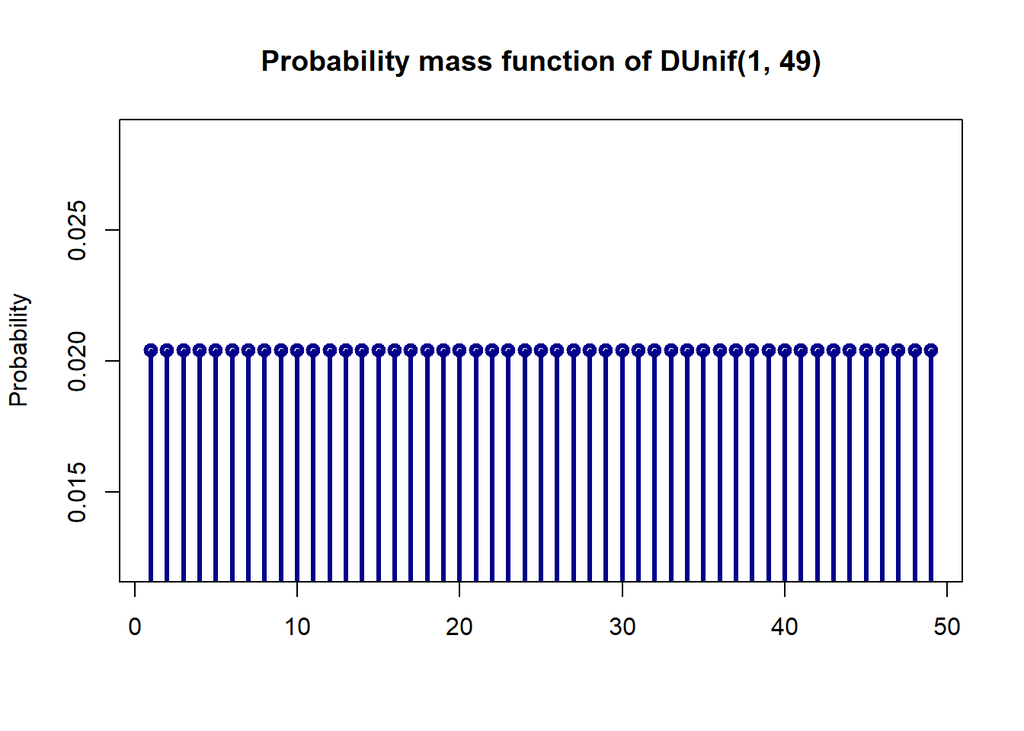

```r
> min <- 1; max <- 49
> n <- max - min + 1
> plot(min:max, rep(1/n, n),
+      main = "Probability mass function of DUnif(1, 49)",
+      xlab = "", ylab = "Probability",
+      type = "h", lwd = 3, col = "darkblue")
> points(min:max, rep(1/n, n),
+        type = "p", lwd = 3, col = "darkblue")
```

**Cumulative distribution function (CDF)**

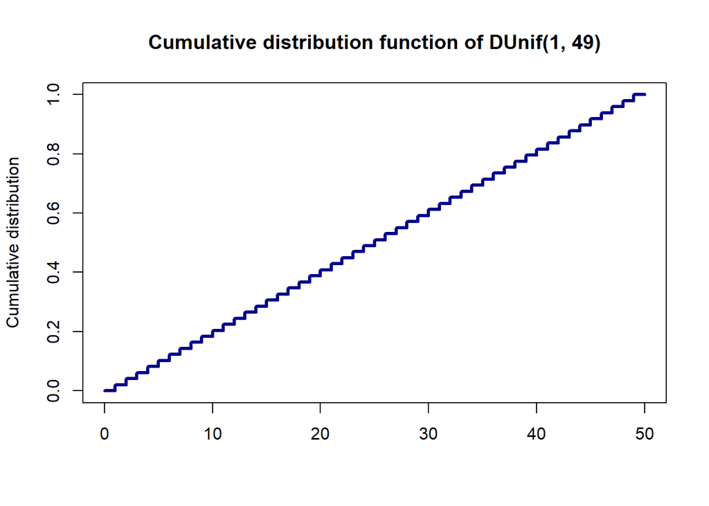

```r
> plot((min-1):(max+1), c(0, cumsum(rep(1/n, n)), 1),
+      main = "Cumulative distribution function of DUnif(1, 49)",
+      xlab = "", ylab = "Cumulative distribution",
+      type = "s", lwd = 3, col = "darkblue")
```

We can simulate drawing a number of six 6 of 49 lottery numbers.

```r
> sample(1:49, size = 1)
[1] 28
```

### Example 4

Simulating drawing 1 card from a deck at random.

First let’s construct our deck of cards.

```r
> cards <- paste(rep(c("Ace",2:10,"Jack","Queen","King"), 4),
+               c("Heart","Diamond","Spade","Club"))
> cards
 [1] "Ace Heart"     "2 Diamond"     "3 Spade"       "4 Club"
 [5] "5 Heart"       "6 Diamond"     "7 Spade"       "8 Club"
 [9] "9 Heart"       "10 Diamond"    "Jack Spade"    "Queen Club"
[13] "King Heart"    "Ace Diamond"   "2 Spade"       "3 Club"
[17] "4 Heart"       "5 Diamond"     "6 Spade"       "7 Club"
[21] "8 Heart"       "9 Diamond"     "10 Spade"      "Jack Club"
[25] "Queen Heart"   "King Diamond"  "Ace Spade"     "2 Club"
[29] "3 Heart"       "4 Diamond"     "5 Spade"       "6 Club"
[33] "7 Heart"       "8 Diamond"     "9 Spade"       "10 Club"
[37] "Jack Heart"    "Queen Diamond" "King Spade"    "Ace Club"
[41] "2 Heart"       "3 Diamond"     "4 Spade"       "5 Club"
[45] "6 Heart"       "7 Diamond"     "8 Spade"       "9 Club"
[49] "10 Heart"      "Jack Diamond"  "Queen Spade"   "King Club"
```

Now we can draw 5 cards from it with replacement. These are 5 realizations of $DUnif(\{deck\})$.

```r
> sample(x = cards, size = 5, replace = TRUE)
[1] "Jack Diamond" "6 Heart"      "King Diamond" "Jack Heart"   "7 Heart"
```

### Example 5

Let’s simulate rolling 2 dice 3 times independently.

Using the `outer` function we an take the product of two arrays. This is our **sample space**.

```r
> dice <- as.vector(outer(1:6, 1:6, paste)); dice
 [1] "1 1" "2 1" "3 1" "4 1" "5 1" "6 1" "1 2" "2 2" "3 2" "4 2" "5 2" "6 2"
[13] "1 3" "2 3" "3 3" "4 3" "5 3" "6 3" "1 4" "2 4" "3 4" "4 4" "5 4" "6 4"
[25] "1 5" "2 5" "3 5" "4 5" "5 5" "6 5" "1 6" "2 6" "3 6" "4 6" "5 6" "6 6"
```

These are ordered couples.

Now we can take 3 elementary outcomes from our sample space with equal probability.

```r
> sample(x = dice, size = 3, replace = TRUE)
[1] "1 2" "2 5" "6 5"
```

## Bernoulli distribution /Бернулиево разпределение/

**Bernoulli distribution**, named after Swiss mathematician **Jacob Bernoulli** is the probability distribution of a random variable which takes the value $1$ with probability $p$ and the value $0$ with probability $q = 1 - p$.
$$X \in Bernoulli(p)$$

If $A$ is an event with probability $p$ then $X$ is frequently called **indicator** of the event $A$ and is denoted by $I_A$.

A special case of binomial distribution random variable $X \in Bi(1, p)$.

**Probability mass function (PMF)**
$$P_X(x_i) = P(X = x_i) = \begin{cases} p, & x_i = 1 \\ q, & x_i = 0 \\ 0, & otherwise \end{cases}$$

**Mean**
$$\mu = p$$
**Variance**
$$\sigma^2 = pq$$

## Binomial distribution /Биномно разпределение/

**Binomial distribution** with parameters $n$ and $p$ represents probability distribution of the number of successes in a sequence of $n$ independent experiments each with probability for success $p$.

$$X \in Bi(n, p)$$

**Probability mass function (PMF)**
$$P_X(k) = P(X = k) = {n \choose k} p^k q^{n-k}, \quad k = 0, 1, ..., n$$

[figure not shown]

$X$ can be represented as sum of $n$ independent indicators of events with probability $p = P(A_i), \: i = 1, ..., n$.
$$X = I_{A_1} + I_{A_2} + ... + I_{A_n}$$

**Mean**
$$\mu = E[X] = E[I_{A_1} + I_{A_2} + ... + I_{A_n}] =$$
$$= E[I_{A_1}] + E[I_{A_2}] + ... + E[I_{A_n}] = p + ... + p = np$$
**Variance**
$$\sigma^2 = D[I_{A_1} + I_{A_2} + ... + I_{A_n}] =$$
As far as the indicators are independent
$$= D[I_{A_1}] + D[I_{A_2}] + ... + D[I_{A_n}] = pq + ... + pq = npq$$

Using the `rbinom` function we can generate a sample of observations of a binomially distributed random variable. The first parameter of the function is how many numbers we want to generate and the next two parameters coincide with the parameters of the binomial distribution.

Let’s generate a realization of $Bi(n, p)$ random variable. This is the same as making $n = 1$ experiment with probability for success $p = 0.5$ and counting the number of successes.

```r
> n <- 1
> p <- 0.5
> rbinom(1, n, p)
[1] 0
```

Let’s generate a realization of $Bi(10, 0.5)$ random variable. This is the same as making ten experiments with probability for success $p = 0.5$ and counting the number of successes.

```r
> n <- 10
> p <- 0.5
> rbinom(1, n, p)
[1] 3
```

Let’s generate 15 realizations of $Bi(10, 0.5)$ random variable. Each of them is the same as making ten experiments with probability for success $p = 0.5$ and counting the number of successes.

```r
> n <- 10
> p <- 0.5
> rbinom(15, n, p)
 [1] 2 5 3 6 4 7 4 5 4 5 5 5 5 5 2
```

Let’s generate 500 realizations of $Bi(10, 0.5)$ random variable.

```r
> x <- rbinom(500, n, p)
```

What is the range of the observations? Estimate the probability for occurrence of each one of them.

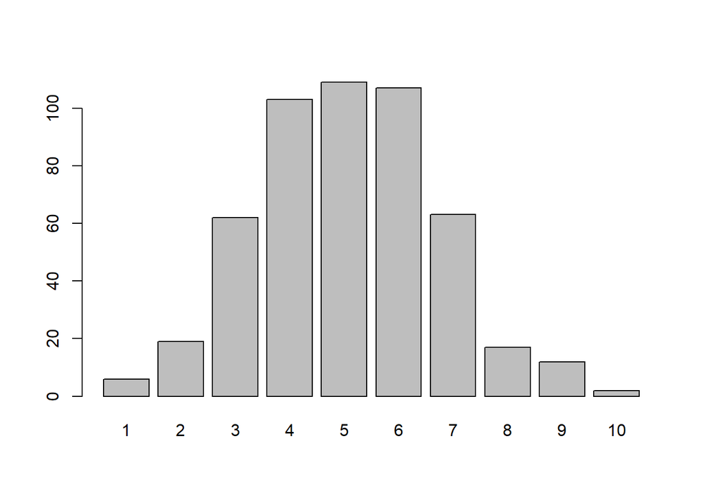

```r
> table(x)
x
  1   2   3   4   5   6   7   8   9  10
  6  19  62 103 109 107  63  17  12   2
> prop.table(table(x))
x
    1     2     3     4     5     6     7     8     9    10
0.012 0.038 0.124 0.206 0.218 0.214 0.126 0.034 0.024 0.004
> barplot(table(x))
```

The corresponding **empirical probability mass function (PMF)** is

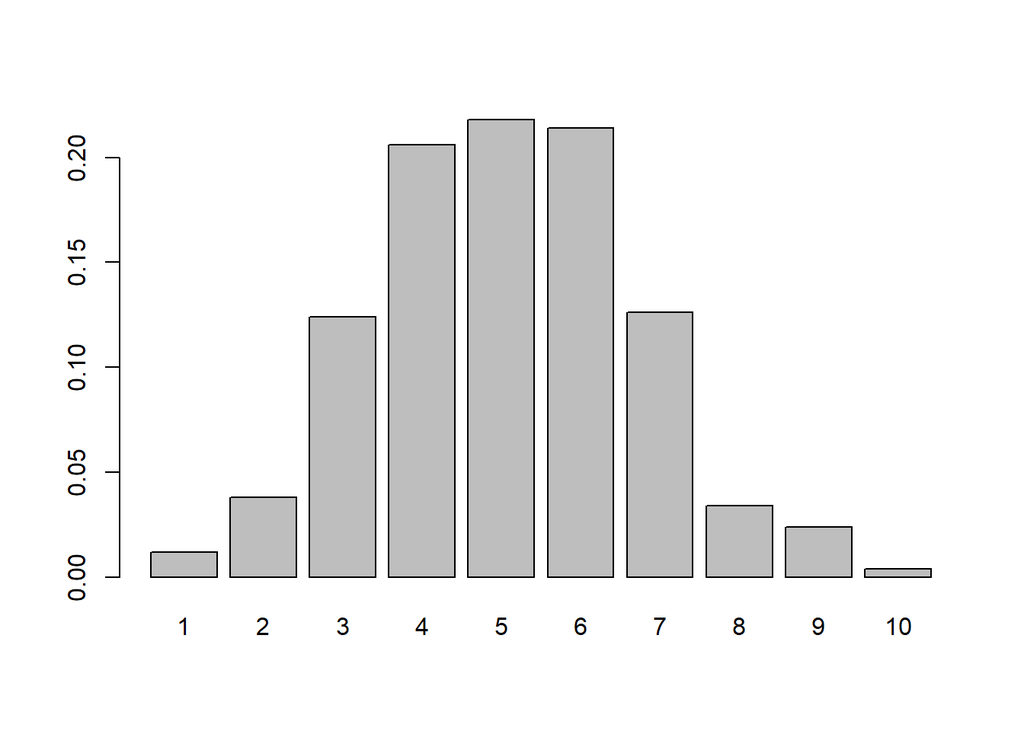

```r
> barplot(prop.table(table(x)))
```

The corresponding **theoretical probability mass function (PMF)** of $Bi(10, 0.5)$ can be computed by using the `dbinom` function

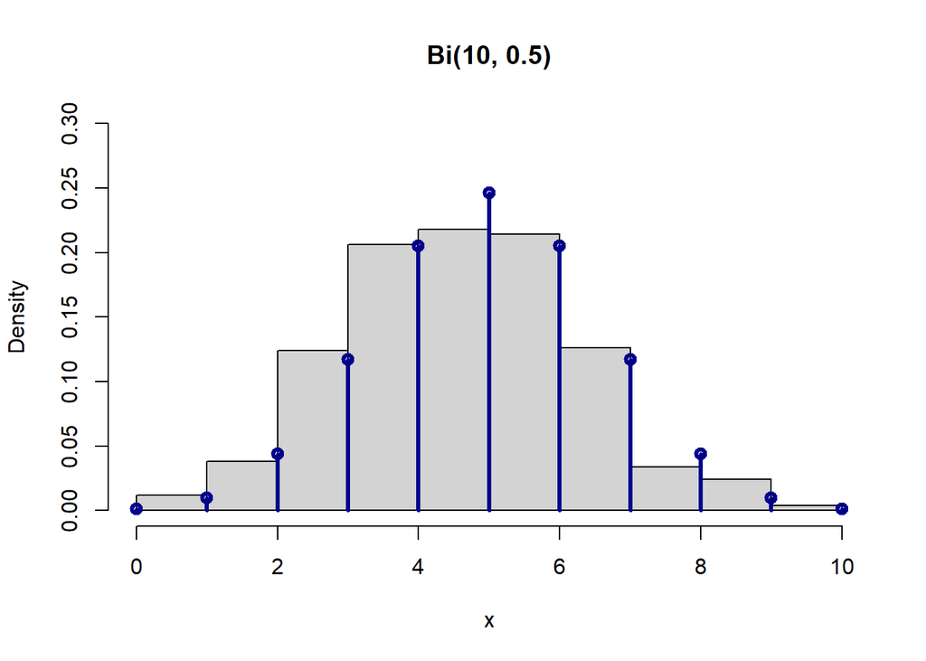

```r
> hist(x,
+      main = "Bi(10, 0.5)" ,
+      breaks = 0:n,
+      probability = TRUE,
+      ylim = c(0, 0.3))
> points(0:n, dbinom(0:n, n, p), type = "h", lwd = 3, col = "darkblue")
> points(0:n, dbinom(0:n, n, p), type = "p", lwd = 3, col = "darkblue")
```

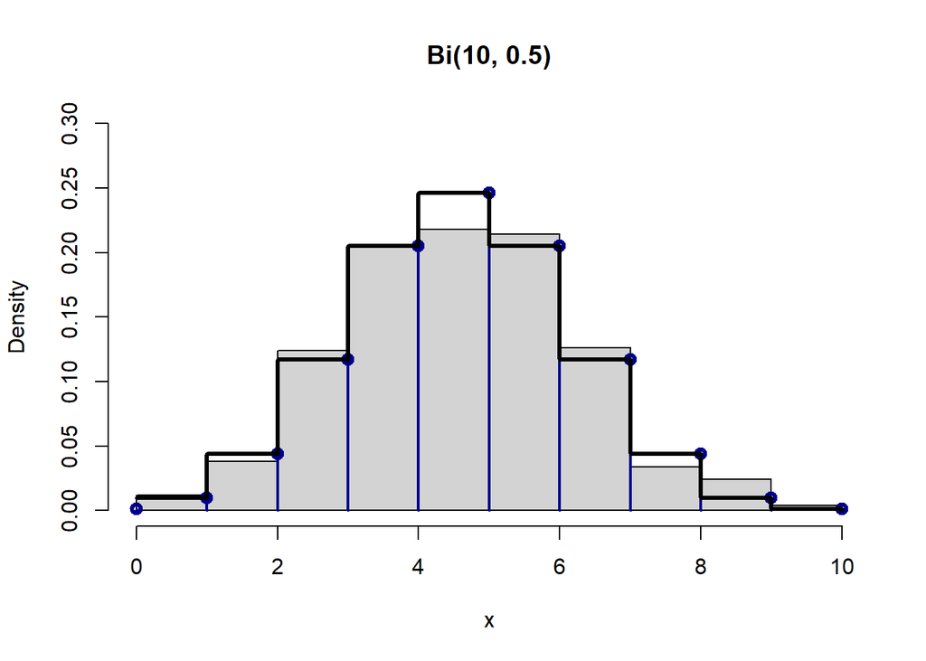

```r
> hist(x,
+      main = "Bi(10, 0.5)" ,
+      breaks = 0:n,
+      probability = TRUE,
+      ylim = c(0, 0.3))
> points(0:n, dbinom(0:n, n, p), type = "h", lwd = 2, col = "darkblue")
> points(0:n, dbinom(0:n, n, p), type = "p", lwd = 3, col = "darkblue")
> points(0:n, dbinom(0:n + 1, n, p), type = "s", lwd = 3)
```

Now let’s generate 5000 realizations of $Bi(10, 0.5)$ random variable.

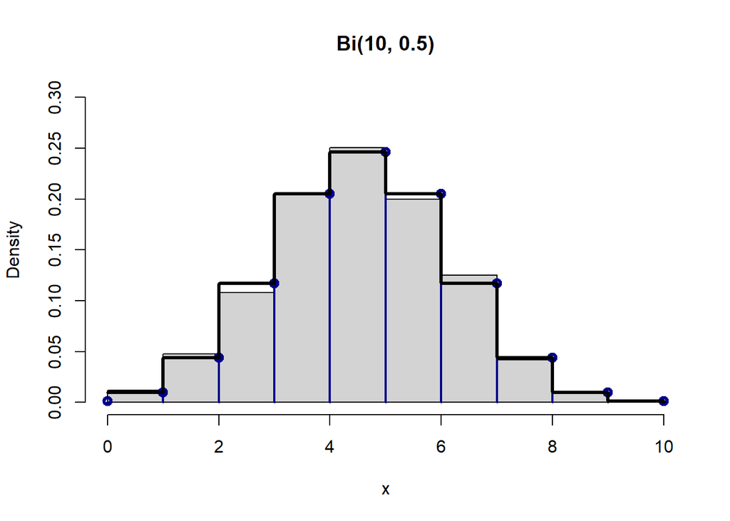

```r
> x <- rbinom(5000, n, p)
> hist(x,
+      main = "Bi(10, 0.5)" ,
+      breaks = 0:n,
+      probability = TRUE,
+      ylim = c(0, 0.3))
> points(0:n, dbinom(0:n, n, p), type = "h", lwd = 2, col = "darkblue")
> points(0:n, dbinom(0:n, n, p), type = "p", lwd = 3, col = "darkblue")
> points(0:n, dbinom(0:n + 1, n, p), type = "s", lwd = 3)
```

Let’s generate 5000 numbers, that are the number of successes in 15 experiments each with probability for success 0.25.

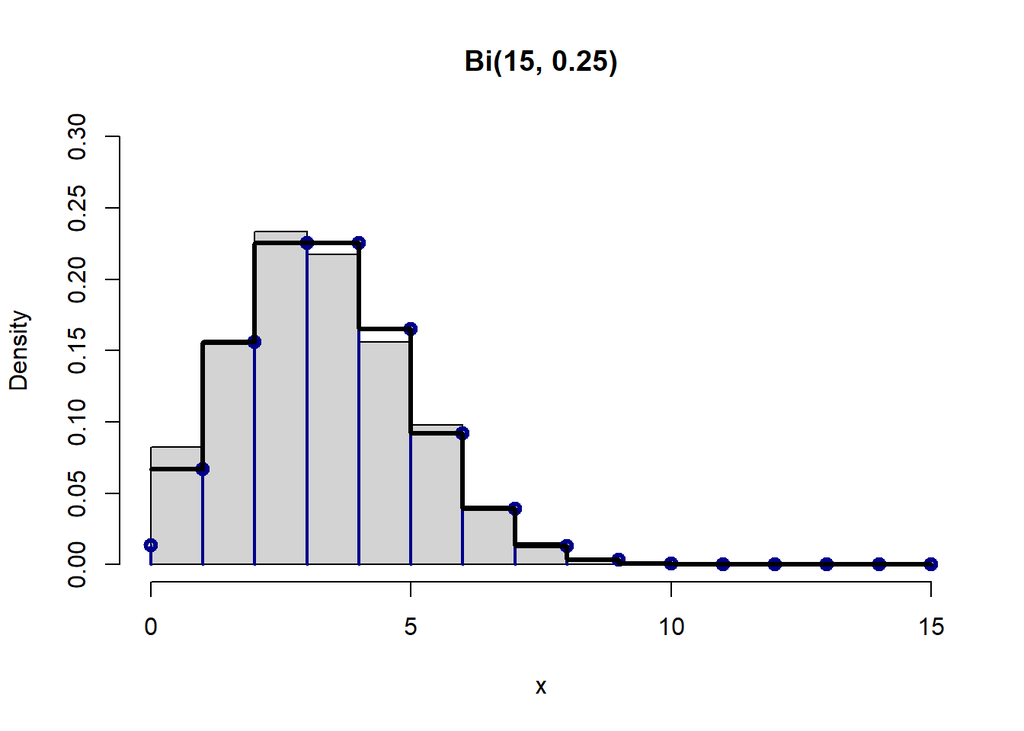

```r
> n <- 15; p <- 0.25
> x <- rbinom(5000, n, p)
> table(x)
x
   0    1    2    3    4    5    6    7    8    9   10   11
  71  340  771 1168 1086  781  489  203   74   13    3    1
> hist(x,
+      main = "Bi(15, 0.25)" ,
+      breaks = 0:n,
+      probability = TRUE,
+      ylim = c(0, 0.3))
> points(0:n, dbinom(0:n, n, p), type = "h", lwd = 2, col = "darkblue")
> points(0:n, dbinom(0:n, n, p), type = "p", lwd = 3, col = "darkblue")
> points(0:n, dbinom(0:n + 1, n, p), type = "s", lwd = 3)
```

Now let’s see how many of the observations are less than or equal to 3.

```r
> sum(x <= 3)
[1] 2350
```

What is the proportion of this observations in the sample?

```r
> sum(x <= 3) / length(x)
[1] 0.47
```

Knowing that the random variable follows $X \in Bi(15, 0.25)$ distribution we can also see the theoretical probability to have an observation less than or equal to 3 using the `pbinom` function.
$$P(X \leq 3)$$

```r
> pbinom(q = 3, size = 15, prob = 0.25)
[1] 0.4612869
```

Is this number similar to the number observed above?

We can also see the theoretical probability to have an observation greater than 3.
$$P(X > 3)$$

```r
> pbinom(q = 3, size = 15, prob = 0.25, lower.tail = FALSE)
[1] 0.5387131
```

or also we can calculate it by using $1 - P(X \leq 3)$

```r
> 1 - pbinom(q = 3, size = 15, prob = 0.25)
[1] 0.5387131
```

The probability $P(X \in (3, 5]) = P(X \leq 5) - P(X \leq 3)$ can be computed by

```r
> pbinom(q = 5, size = 15, prob = 0.25) - pbinom(q = 3, size = 15, prob = 0.25)
[1] 0.390345
```

The probability $P(X \in [3, 5]) = P(X \leq 5) - P(X \leq 2)$ can be computed by

```r
> pbinom(q = 5, size = 15, prob = 0.25) - pbinom(q = 2, size = 15, prob = 0.25)
[1] 0.6155441
```

or by using $P(X \in [3, 5]) = P(X = 3) + P(X = 4) + P(X = 5)$

```r
> sum(dbinom(x = c(3,4,5), size = 15, prob = 0.25))
[1] 0.6155441
```

By using `qbinom` function we can compute $0.4$ quantile of $X$. It is the smallest number when the CDF of $X$ is bigger than or equal to $0.4$.
$$X_{0.4} = min\{x \in \mathbb{R} : P(X \leq x) \geq 0.4\}$$

```r
> qbinom(p = 0.4, size = 15, prob = 0.25)
[1] 3
```

and also the quantile from which we have 0.4 probability to be higher

```r
> qbinom(p = 0.4, size = 15, prob = 0.25, lower.tail = FALSE)
[1] 4
```

## Geometric distribution /Геометрично разпределение/

There are two definitions for the geometric distribution.

Let’s say we are making independent repetitions of an experiment. The first definition of **geometric distribution** with parameter $p$ represents probability distribution of the number of the first success. The second definition represents probability distribution of the number of failures before the first success. We are going to use the second one.

$$X \in Ge(p)$$

Geometric distribution is a special case of **Negative binomial distribution** $NegBi(1, p)$.

**Probability mass function (PMF)**
$$P_X(k) = P(X = k) = q^k p, \quad k = 0,1,...$$

[figure not shown]

**Mean**
$$\mu = E[X]= \int_{-\infty}^{+\infty}{xdF_X(x)} =
\sum_{i=0}^{\infty}{iP(X = i)} =$$
$$= \sum_{i=0}^{\infty}i q^i p = pq\sum _{i=0}^{\infty}{iq^{i-1}} =$$
$$= pq\frac{\partial }{\partial q}\left(\sum_{i=0}^{\infty}{q^i}\right) = pq\frac{\partial }{\partial q}\left(\frac{1}{1-q}\right) =$$
$$= pq\frac{-1}{(1-q)^2}(-1) = \frac{pq}{p^2} =$$
$$= \frac{q}{p}$$
**Variance**
$$\sigma^2 = \frac{q}{p^2}$$
Similarly as above we can use the functions `dgeom`, `rgeom`, `pgeom` and `qgeom` to find the theoretical probability mass function, to generate random numbers, to find the cumulative distribution function and quantiles of geometrically distributed random variable.

Let’s generate a realization of $Geom(0.2)$ random variable.

```r
> rgeom(1, 0.2)
[1] 5
```

This number represents the number of failures before the first success.

Let’s generate 10 realizations of $Geom(0.2)$ random variable.

```r
> rgeom(10, 0.2)
 [1]  2 19  2  0  1  2 15  1 10  0
```

### Example

Let’s generate 500 random numbers representing the number of failures before the first row of 6 on a regular die.

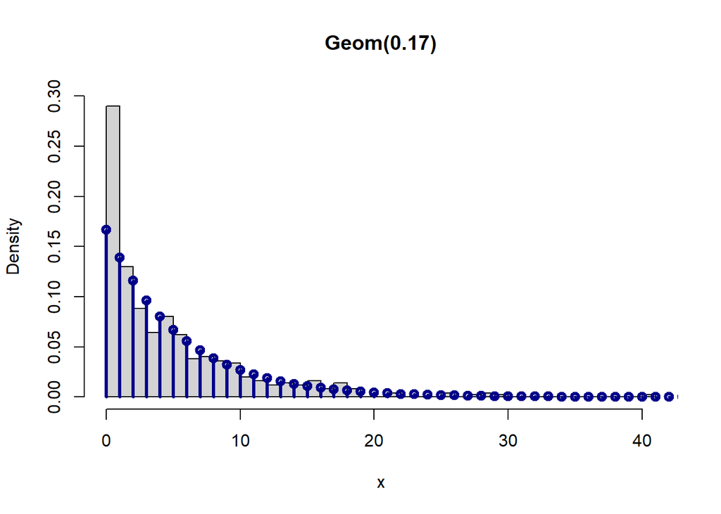

```r
> p <- 1/6
> x <- rgeom(500, p)
> hist(x,
+      main = "Geom(0.17)" ,
+      breaks = 0:max(x),
+      probability = TRUE,
+      ylim = c(0, 0.3))
> points(0:100, dgeom(0:100,p), type = "h", lwd = 3, col = "darkblue")
> points(0:100, dgeom(0:100,p), type = "p", lwd = 3, col = "darkblue")
```

Now let’s see how many time the 6 is observed before the 3rd row of the die.

```r
> sum(x <= 2)
[1] 210
```

What is the proportion of this outcomes in the sample?

```r
> sum(x <= 2) / length(x)
[1] 0.42
```

```r
> pgeom(q = 2, p)
[1] 0.4212963
```

We can also see the probability to row 6 for the first time between the 6th and 3rd row of the die.

```r
> pgeom(q = 5, p) - pgeom(q = 2, p)
[1] 0.2438057
```

Or we can see the theoretical quantile from which we have 0.5 probability to have 6 for the first time before that row.

```r
> qgeom(p = 0.5, p)
[1] 3
```

## Negative binomial distribution /Отрицателно биномно разпределение/

Let’s say we are making independent repetitions of an experiment, each with probability for success $p$. **Negative binomial distribution** with parameters $n$ and $p$ represents probability distribution of the number of failures before the n-th success occur.
$$X \in NegBi(n, p)$$
**Probability mass function (PMF)**
$$P_X(k) = P(X = k) = {n + k - 1 \choose k} q^k p^n, \quad k = 0, 1, ...$$
$X$ can be represented as sum of $n$ independent geometrically distributed random variables $Y_i \in Ge(p) \: i = 1, ..., n$.
$$X = Y_1 + Y_2 + ... + Y_n$$

**Mean**
$$\mu = E[X] = E[Y_1 + Y_2 + ... + Y_n] =$$
$$= E[Y_1] + E[Y_2] + ... + E[Y_n] = \frac{q}{p} + ... + \frac{q}{p} = n\frac{q}{p}$$
**Variance**
$$\sigma^2 = D[Y_1 + Y_2 + ... + Y_n] =$$
As far as the geometric random variables are independent
$$= D[Y_1] + D[Y_2] + ... + D[Y_n] = \frac{q}{p^2} + ... + \frac{q}{p^2} = n\frac{q}{p^2}$$
Similarly as above we can use the functions `dnbinom`, `rnbinom`, `pnbinom` and `qnbinom` to find the theoretical probability mass function, to generate random numbers, to find the cumulative distribution function and quantiles of negative binomial distributed variable.

Let’s generate a realization of $NegBi(5, 0.2)$ representing the number of failures before the 5th success, when the probability for success in every one of the experiments is 0.2.

```r
> rnbinom(1, 5, 0.2)
[1] 21
```

Let’s generate 10 realizations of $NegBi(5, 0.2)$ random variable.

```r
> rnbinom(10, 5, 0.2)
 [1] 29 13 19 11 28 26 13 18  6 28
```

### Example

Let’s have a regular die and say rolling of 6 is a success and event $X$ models the number of failures before the 3rd row of 6.

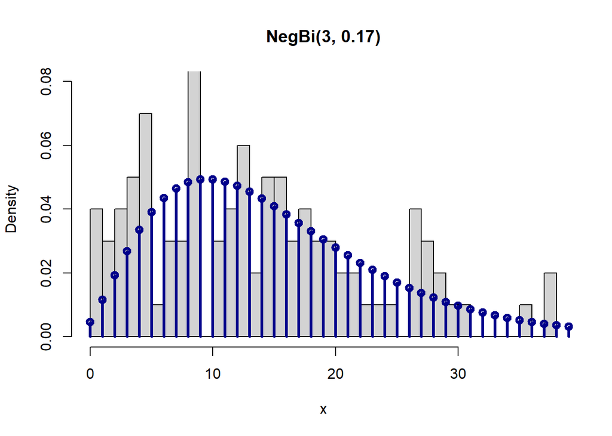

```r
> n <- 3; p <- 1/6
> x <- rnbinom(100, n, p)
> hist(x,
+      main = "NegBi(3, 0.17)" ,
+      breaks = 0:max(x),
+      probability = TRUE,
+      ylim = c(0, 0.08))
> points(0:100, dnbinom(0:100, n, p), type = "h", lwd = 3, col = "darkblue")
> points(0:100, dnbinom(0:100, n, p), type = "p", lwd = 3, col = "darkblue")
```

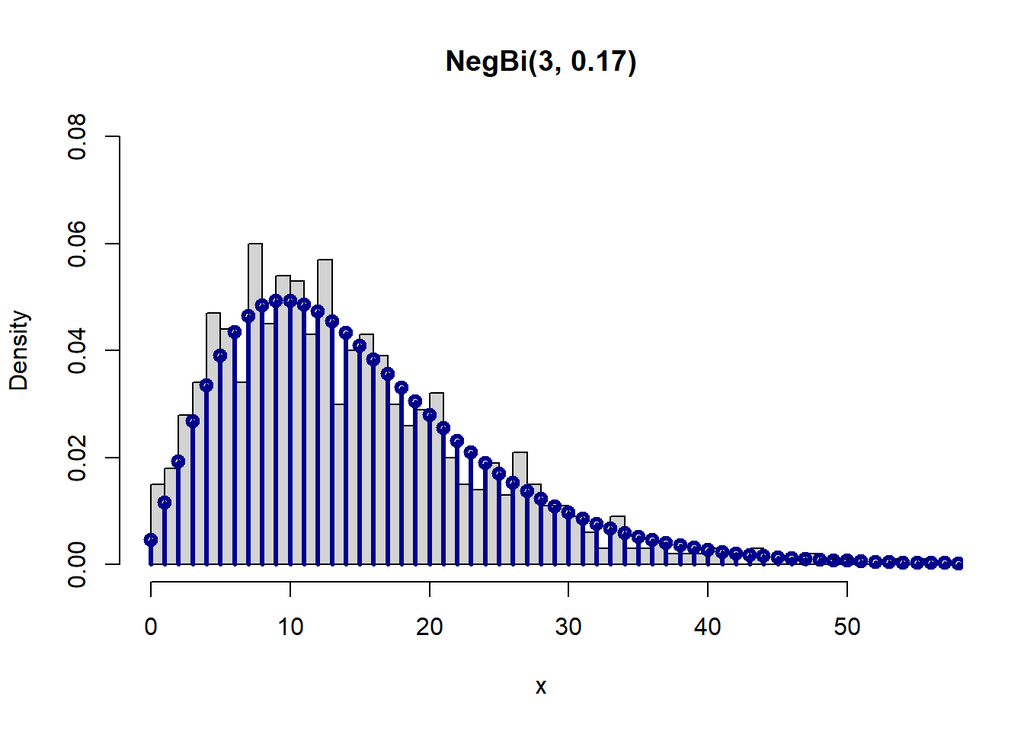

```r
> n <- 3; p <- 1/6
> x <- rnbinom(1000, n, p)
> hist(x,
+      main = "NegBi(3, 0.17)" ,
+      breaks = 0:max(x),
+      probability = TRUE,
+      ylim = c(0, 0.08))
> points(0:100, dnbinom(0:100, n, p), type = "h", lwd = 3, col = "darkblue")
> points(0:100, dnbinom(0:100, n, p), type = "p", lwd = 3, col = "darkblue")
```

```r
> pnbinom(5, n, p)
[1] 0.1348469
```

```r
> pnbinom(10, n, p) - pnbinom(4, n, p)
[1] 0.2761473
```

```r
> qnbinom(0.5, n, p)
[1] 13
```